Social Reaction and Critical Models of Crime

# Labeling Theory

## Labeling Theory

No act is inherently deviant - deviance is created by social reactions

“Deviant” labels are socially applied

Once labeled, individuals may see themselves through that deviant label

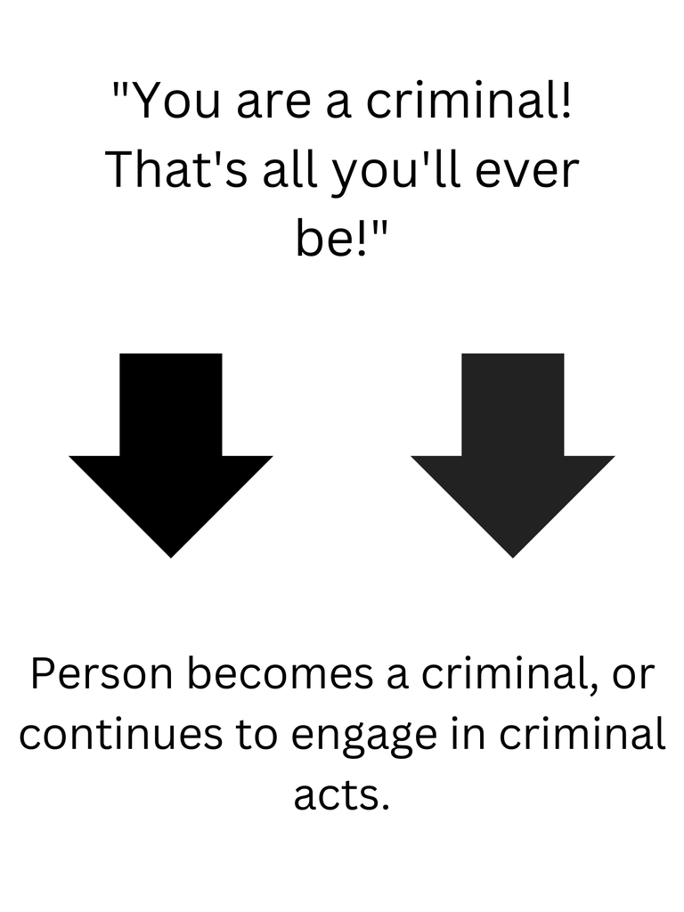

## Primary vs. Secondary Deviance

Primary Deviance:

Initial, often minor rule-breaking (e.g., underage drinking) that typically doesn’t alter self-image

Example: A teen shoplifts once, isn’t caught, doesn’t adopt a “thief” identity

Secondary Deviance:

Further deviance caused by society’s reaction and the internalization of a deviant label

Example: The teen is publicly labeled a “thief,” shunned, and then embraces that identity by committing more thefts

## The Labeling Process

1️⃣ Initial Act (Primary Deviance): Usually minor, goes unnoticed or unpunished

2️⃣ Detection & Labeling: Authorities or community apply a formal deviant label

3️⃣ Stigmatization: Person faces social rejection; opportunities narrow

4️⃣ Internalization: The label becomes part of self-identity, fueling continued deviance (Secondary Deviance)

## Criticisms of Labeling Theory

Overlooks why deviance starts in the first place

Often used alongside other theories to fully explain criminal behavior

Difficult to test empirically

# Marxist Criminology

## Russian Revolution of 1917

Economic inequalities between the bourgeoisie and the proletariat

Bourgeoisie class - ruling class that owns the means of production

Proletariat class - working class that sells their labor

*The Communist Manifesto* (1848), inspired many to believe that a proletarian-led revolution could overthrow the Bourgeoisie class and abolish the idea of private property and creating a classless society

*Das Kapital* (1867) explored how workers are exploited through production - the actual process of work. Argued that the capitalist purchased labourers’ capacity to work, not their labour

## Russian Revolution of 1917

1️⃣ February Revolution - Overthrew the Tsar Nicholas II

2️⃣ October Revolution - Led by the Bolsheviks under Vladimir Lenin, this second revolution placed power in the hands of the Soviets (worker councils), marking the first major communist state

A civil war between the Bolshevik Red Army and anti-Bolshevik forces ensued

The Bolsheviks emerged victorious, establishing the Union of Soviet Socialist Republics (USSR) around 1922

## Marxist Criminology

Examines how crime and law are shaped by social and economic structures, emphasizing class conflict

Major tenants:

Capitalism fosters an environment of competition and inequality, which leads to criminal behavior within the economic system

Laws are created and enforced in ways that protect the interests of the bourgeoisie (ruling class) and maintain their dominance over the proletariat (working class)

Criticisms:

Too simplistic. It is unlikely that capitilism is the only casues of crime, and that a socialist economy would solve all crime.

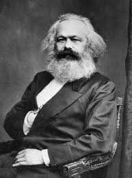

# Group Discussion!!!!

## Group Discussion

`10:00`

How might the revolutionary ideas that led to the Russian Revolution of 1917 compare to today’s political and social movements — such as “Hands Off” protests, concerns over an economic recession, healthcare debates, or the funding pressures faced by Columbia amid Palestinian protests?

In your view, can any contemporary acts of civil disobedience or crime be explained through a Marxist lens, and if so, would those actions be justifiable?

Make a stance on the justice element and have an argument for your choice. Elect one speaker to present your point.

Speak your mind!

# Questions before exam?

## Good luck studying

[figure not shown]

image: giphy